# Exercise #1 — Distributions, Simulation, and the Log-Likelihood (Answers)

PLSC 606J, Fall 2026

Author

Affiliation

Dave Clark

Binghamton University

Published

August 26, 2026

Answer key for Exercise #1. The code is folded — open it to see how a piece was built.

# Part I — Distributions and links

> For this section, please write out all PDF/CDF equations — that is, do **not** use built-in R functions (`plogis`, `dlogis`, `pcauchy`, `dnorm` and so on) **except for `pnorm`** (so you don’t have to write the integral). Write the equations yourself.

The logistic and Cauchy have closed-form CDFs, $\Lambda(z) = 1/(1 + e^{-z})$ and $F(z) = \tfrac{1}{2} + \tfrac{1}{\pi}\arctan(z)$. The normal does not, which is why R ships `pnorm` and why it is the one built-in the exercise allows. I accumulate the normal PDF with the trapezoid rule anyway, so you see once what “the integral of the density” means.

## 1. CDFs and PDFs

> **1.** Please replicate this figure. What do the PDFs describe? What do the CDFs describe?

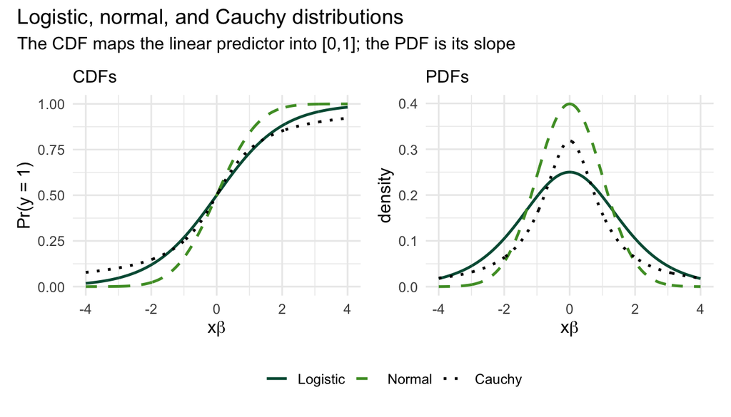

Figure 1

```r
z  <- seq(-4, 4, length.out = 1000)
dz <- z[2] - z[1]

# Normal: density written by hand, then accumulated to get the CDF. The
# trapezoid rule averages consecutive heights. This is Phi(z) - Phi(-4); the
# mass below -4 is about .00003.
normal_pdf <- (1 / sqrt(2 * pi)) * exp(-z^2 / 2)
normal_cdf <- c(0, cumsum((head(normal_pdf, -1) + tail(normal_pdf, -1)) / 2 * dz))

dists <- tibble(
  z,
  Logistic = 1 / (1 + exp(-z)),
  Normal   = normal_cdf,
  Cauchy   = 0.5 + atan(z) / pi
) %>%
  pivot_longer(-z, names_to = "distribution", values_to = "cdf") %>%
  mutate(distribution = factor(distribution, levels = c("Logistic", "Normal", "Cauchy")))

densities <- tibble(
  z,
  Logistic = exp(-z) / (1 + exp(-z))^2,
  Normal   = normal_pdf,
  Cauchy   = 1 / (pi * (1 + z^2))
) %>%
  pivot_longer(-z, names_to = "distribution", values_to = "pdf") %>%
  mutate(distribution = factor(distribution, levels = c("Logistic", "Normal", "Cauchy")))

p_cdf <- ggplot(dists, aes(z, cdf, color = distribution, linetype = distribution)) +
  geom_line(linewidth = 0.9) +
  scale_color_manual(values = series_colors) +
  scale_linetype_manual(values = series_lines) +
  labs(title = "CDFs", x = expression(x*beta), y = "Pr(y = 1)",
       color = NULL, linetype = NULL) +
  theme_bu() +
  theme(legend.position = "bottom", plot.title = element_text(size = 12))

p_pdf <- ggplot(densities, aes(z, pdf, color = distribution, linetype = distribution)) +
  geom_line(linewidth = 0.9) +
  scale_color_manual(values = series_colors) +
  scale_linetype_manual(values = series_lines) +
  labs(title = "PDFs", x = expression(x*beta), y = "density",
       color = NULL, linetype = NULL) +
  theme_bu() +
  theme(legend.position = "bottom", plot.title = element_text(size = 12))

(p_cdf + p_pdf) +
  plot_layout(guides = "collect") +
  plot_annotation(
    title = "Logistic, normal, and Cauchy distributions",
    subtitle = "The CDF maps the linear predictor into [0,1]; the PDF is its slope",
    theme = theme_bu()
  ) &
  theme(legend.position = "bottom")
```

**The CDF** returns $Pr(y = 1)$ at any value of $x\beta$ — probability accumulated up to that point. It takes the real line, where $x\beta$ lives, and squashes it into $[0,1]$, where a probability has to live.

**The PDF** is its derivative: how *fast* the probability changes at a given $x\beta$. Tallest where the CDF is steepest, near zero in the tails where the CDF has flattened. A marginal effect is a slope, so this is the curve we want later.

## 2. Three links

> **2.** Please replicate this figure — it overlays the CDFs of the logistic, the complementary log-log (cloglog), and the log-log. Comment on the differences among the three.

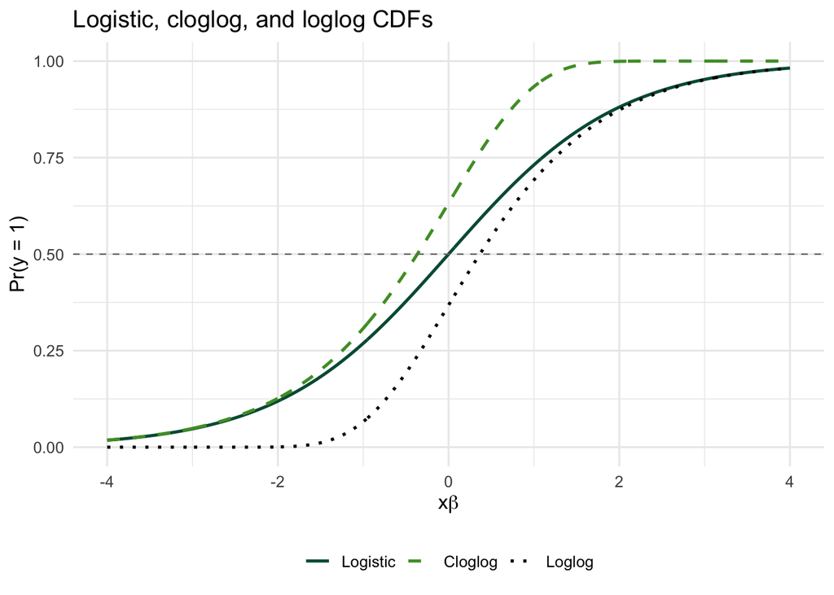

Figure 2

```r
links <- tibble(
  z,
  Logistic = 1 / (1 + exp(-z)),
  Cloglog  = 1 - exp(-exp(z)),
  Loglog   = exp(-exp(-z))
) %>%
  pivot_longer(-z, names_to = "link", values_to = "p") %>%
  mutate(link = factor(link, levels = c("Logistic", "Cloglog", "Loglog")))

ggplot(links, aes(z, p, color = link, linetype = link)) +
  geom_line(linewidth = 0.9) +
  geom_hline(yintercept = 0.5, color = bu_grey, linetype = "dashed", linewidth = 0.4) +
  scale_color_manual(values = series_colors) +
  scale_linetype_manual(values = series_lines) +
  labs(title = "Logistic, cloglog, and loglog CDFs",
       x = expression(x*beta), y = "Pr(y = 1)",
       color = NULL, linetype = NULL) +
  theme_bu() +
  theme(legend.position = "bottom")
```

The logistic is **symmetric**: $\Lambda(-z) = 1 - \Lambda(z)$, so it crosses .5 at $x\beta = 0$ and approaches 1 the way it approaches 0, run backwards. The cloglog and loglog are **asymmetric**, and they mirror each other rather than themselves. The cloglog, $1 - \exp(-\exp(z))$, leaves zero gradually then rushes to one, crossing .5 at about $-0.37$; the loglog does the reverse, crossing at about $+0.37$.

That asymmetry is why we keep them. When ones are rare the action is in the bottom left, and that is where the three disagree most: a link that leaves zero slowly puts more mass down there than the logit does at the same $x\beta$, one that leaves abruptly puts less. We are asking the data to tell very small probabilities apart, so the shape of that tail does real work. Hence the cloglog in rare-events work and in discrete-time hazards, where it is also the exact discrete-time analogue of a constant underlying hazard.

## 3. Intercept shifts

> **3.** Please replicate this figure — it overlays the logistic CDF with intercepts of $-1$, $0$, and $+1$. Please describe what happens as the intercept changes. Then compare these intercept shifts to intercept shifts in the **linear** model: how are the two similar, and how are they different?

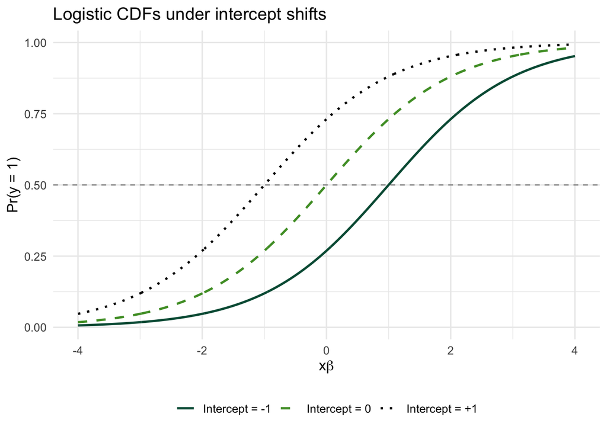

Figure 3

```r
shifts <- tibble(
  z,
  `Intercept = -1` = 1 / (1 + exp(-(z - 1))),
  `Intercept = 0`  = 1 / (1 + exp(-z)),
  `Intercept = +1` = 1 / (1 + exp(-(z + 1)))
) %>%
  pivot_longer(-z, names_to = "intercept", values_to = "p") %>%
  mutate(intercept = factor(intercept,
                            levels = c("Intercept = -1", "Intercept = 0", "Intercept = +1")))

ggplot(shifts, aes(z, p, color = intercept, linetype = intercept)) +
  geom_line(linewidth = 0.9) +
  geom_hline(yintercept = 0.5, color = bu_grey, linetype = "dashed", linewidth = 0.4) +
  scale_color_manual(values = series_colors) +
  scale_linetype_manual(values = series_lines) +
  labs(title = "Logistic CDFs under intercept shifts",
       x = expression(x*beta), y = "Pr(y = 1)",
       color = NULL, linetype = NULL) +
  theme_bu() +
  theme(legend.position = "bottom")
```

Changing the intercept **slides the curve sideways** and does nothing else. Raise it by one and the curve moves one unit left, so the probability reaches one-half one unit earlier. Steepness and tails are identical across all three.

**Same as the linear model:** the intercept sets the level and leaves the slopes alone. Add $c$ and every $x\beta$ goes up by $c$. On the $x\beta$ scale the logit *is* linear, so the two behave identically there.

**Different from the linear model** on the scale we care about. In OLS the prediction *is* $x\beta$, so a one-unit shift moves predicted $y$ one unit, everywhere, for everybody. In the logit the prediction is $\Lambda(x\beta)$, so the same shift moves the probability a lot in the steep middle and hardly at all in the flat tails — off the figure, about .23 at $x\beta = 0$ and about .03 at $x\beta = -4$. Constant on the $x\beta$ scale, not constant on the probability scale. That is why a logit coefficient is not a marginal effect.

## 4. The skewed logit (scobit)

> **4.** Please replicate this figure — it overlays the skewed logit (scobit) CDF at shape parameters $\alpha = 1$, $\alpha = 2$, and $\alpha = 0.5$. Please describe what happens as the shape parameter changes. How are these curves similar to, and different from, the logistic CDF in question 3?

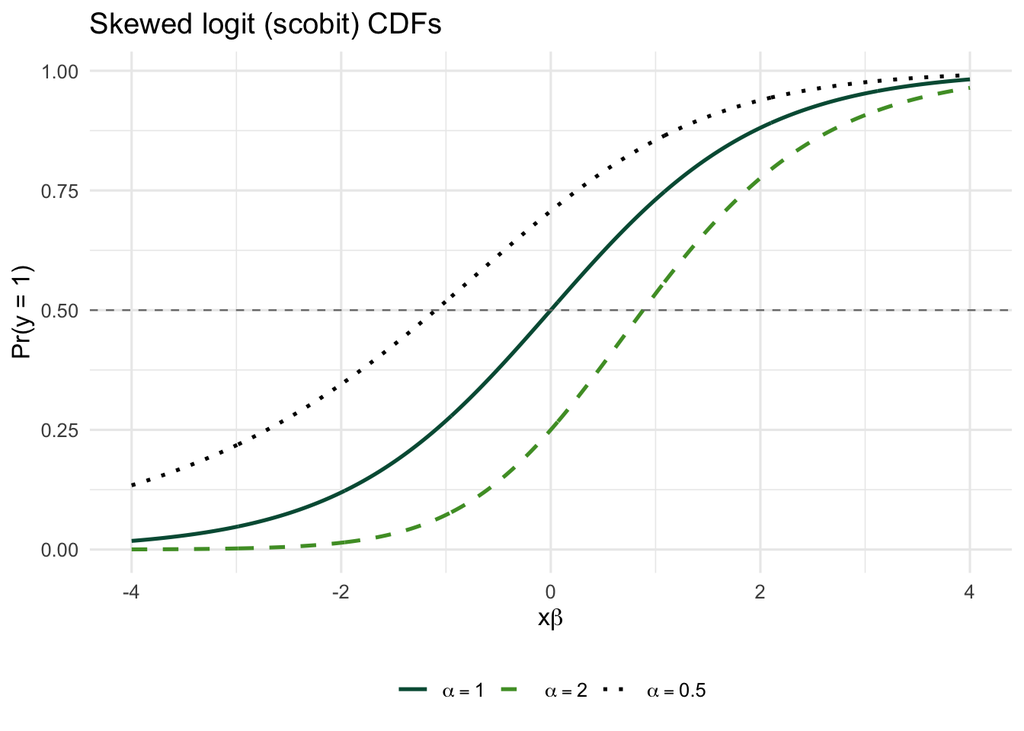

Figure 4

```r
scobit <- tibble(
  z,
  `alpha = 1`   = 1 / (1 + exp(-z))^1,
  `alpha = 2`   = 1 / (1 + exp(-z))^2,
  `alpha = 0.5` = 1 / (1 + exp(-z))^0.5
) %>%
  pivot_longer(-z, names_to = "shape", values_to = "p") %>%
  mutate(shape = factor(shape, levels = c("alpha = 1", "alpha = 2", "alpha = 0.5")))

ggplot(scobit, aes(z, p, color = shape, linetype = shape)) +
  geom_line(linewidth = 0.9) +
  geom_hline(yintercept = 0.5, color = bu_grey, linetype = "dashed", linewidth = 0.4) +
  scale_color_manual(values = series_colors,
                     labels = c(expression(alpha == 1), expression(alpha == 2),
                                expression(alpha == 0.5))) +
  scale_linetype_manual(values = series_lines,
                        labels = c(expression(alpha == 1), expression(alpha == 2),
                                   expression(alpha == 0.5))) +
  labs(title = "Skewed logit (scobit) CDFs",
       x = expression(x*beta), y = "Pr(y = 1)",
       color = NULL, linetype = NULL) +
  theme_bu() +
  theme(legend.position = "bottom")
```

At $\alpha = 1$ the scobit **is** the logit — raise $(1 + e^{-z})^{-1}$ to the first power and you have written $\Lambda(z)$. The logit is the special case, so “is the logit good enough here?” becomes a hypothesis about a single number rather than a matter of taste.

Move $\alpha$ off 1 and the curve **bends**, which is a different operation from question 3. An intercept shift is a rigid translation — same curve, new location. Changing $\alpha$ deforms it: the steepest point moves off $Pr(y = 1) = .5$ and the tails stop mirroring each other. At $\alpha = 2$ the curve hugs zero longer and is steepest *below* .5; at $\alpha = 0.5$ it lifts off early and is steepest *above* .5.

Nagler’s motivation: the logit forces the largest marginal effects to land at $Pr(y = 1) = .5$, for everyone, always, by construction. That is an assumption, and a strong one. If the people most responsive to $x$ are not the ones sitting at fifty-fifty — for turnout, the argument is that they are not — you want that location estimated rather than imposed. That is what $\alpha$ does.

# Part II — Simulation and the log-likelihood

## 5. Simulate a binary outcome

> **5.** Please write code that simulates data for a binary $y$ variable from the equation $x\beta = \beta_0 + \beta_1 x_1 + \beta_2 x_2$, with $\beta_0 = -1$, $\beta_1 = 0.5$, and $\beta_2 = -0.5$, with a **logit** link. Let $x_1$ be continuous and $x_2$ be binary. The output should be a data frame of 1,000 observations containing a binary $y$, a constant, and the two $x$ variables.

The data-generating process, stated before any code is written:

$$\begin{aligned}
x_{1i} &\sim \text{Normal}(0,1), \qquad x_{2i} \sim \text{Bernoulli}(0.5) \\
x_i\beta &= -1 + 0.5\,x_{1i} - 0.5\,x_{2i} \\
\pi_i &= \Lambda(x_i\beta) \;=\; \frac{1}{1 + e^{-x_i\beta}} \\
y_i &\sim \text{Bernoulli}(\pi_i)
\end{aligned}$$

The third line is the link: take $x_i\beta$, free to be any real number, and hand back a probability. Write $\Phi(x_i\beta)$ instead and you have simulated a probit; write $1 - \exp(-\exp(x_i\beta))$ and you have a cloglog. Nothing above or below that line changes.

The last two lines are the model. The systematic part produces a *probability*, one per observation; the stochastic part turns it into a zero or a one with a coin weighted by $\pi_i$. Two observations with identical $x$’s get identical $\pi$’s and can still get different $y$’s. That is why we estimate $\pi$ rather than $y$.

```r
set.seed(8675309)

n  <- 1000
x1 <- rnorm(n)                # continuous
x2 <- rbinom(n, 1, 0.5)       # binary

xb <- -1 + 0.5 * x1 - 0.5 * x2

# The logit link, written out rather than calling plogis(). Call it `pr`, not
# `pi` -- in R, `pi` is already 3.14159..., and overwriting it breaks any later
# line that needs the real one.
pr <- 1 / (1 + exp(-xb))
y  <- rbinom(n, 1, pr)        # the coin flip: y is random even given pr

sim <- tibble(y, const = 1, x1, x2)

c(n = n, share_ones = round(mean(sim$y), 3), mean_pr = round(mean(pr), 3))
```

```
         n share_ones    mean_pr
  1000.000      0.239      0.236
```

About 0.239 of the observations are ones, close to the mean of the $\pi_i$’s, 0.236, as it should be. Both sit below one-half, which is what the $-1$ intercept gets us: at $x_1 = 0$, $x_2 = 0$ the probability is $\Lambda(-1) = 0.269$.

We also have the **true** $\beta = (-1, 0.5, -0.5)$, because we chose it. In real data we never do, which is why simulated data is the place to test an estimator like this.

## 6. The likelihood and log-likelihood

> **6.** Please write (in proper math notation, not code) the **likelihood** and **log-likelihood** functions for a binary $y$ variable using the **logit** as the link function. Describe the parts of the log-likelihood and what each is doing.

Start with the general form; it is the same for every binary model, and only one piece changes. Each observation contributes the probability of the outcome we observed for it: $\pi_i$ when $y_i = 1$, $1 - \pi_i$ when $y_i = 0$. Putting $y_i$ and $1 - y_i$ in the exponents writes that as one term — one exponent is always zero, so one factor always drops out.

$$\begin{aligned}
L(\beta \mid y) &= \prod_{i=1}^{n} \pi_i^{\,y_i}\,(1 - \pi_i)^{\,1 - y_i} \\
\ell(\beta \mid y) &= \ln L(\beta \mid y)
= \sum_{i=1}^{n}\Big[\, y_i \ln \pi_i + (1 - y_i)\ln(1 - \pi_i)\Big]
\end{aligned}$$

with $\pi_i = F(x_i\beta)$ for whatever link $F$ we chose. For the logit, $\pi_i = \Lambda(x_i\beta) = 1/(1 + e^{-x_i\beta})$, and

$$\begin{aligned}
L(\beta \mid y) &= \prod_{i=1}^{n} \Lambda(x_i\beta)^{\,y_i}\,
\big[1 - \Lambda(x_i\beta)\big]^{\,1 - y_i} \\
\ell(\beta \mid y) &= \sum_{i=1}^{n} \Big[\, y_i \ln \Lambda(x_i\beta)
+ (1 - y_i)\ln\big(1 - \Lambda(x_i\beta)\big) \Big]
\end{aligned}$$

Note where the link sits — inside both terms and nowhere else. Swap $\Lambda$ for $\Phi$ and you have the probit; exchange it for $1 - \exp(-\exp(\cdot))$ and you have the cloglog.

## 7. The log-likelihood in R

> **7.** Please write the log-likelihood function from above in R code, as a `function`. It should take as arguments a vector of parameters, a matrix of $X$ variables, and a $y$ variable, and return a single number (the log-likelihood). Using the data from question #5 for $X$ and $y$, evaluate the log-likelihood at the **true** $\beta$’s from question #5; the $\beta$’s from a `glm` logit of the data and equation from question #5; $\beta$ values of 0, 0, 0; and $\beta$ values of 1, -.5, .5. Present the log-likelihoods in a professional table and comment.

```r
# Build xb, transform it through the link to get probabilities, sum the two
# terms. Three arguments in, one number out.
logit_ll <- function(beta, X, y) {
  xb <- as.vector(X %*% beta)
  p  <- 1 / (1 + exp(-xb))
  sum(y * log(p) + (1 - y) * log(1 - p))
}

X <- cbind(const = 1, x1 = sim$x1, x2 = sim$x2)

b_hat <- coef(glm(y ~ x1 + x2, family = binomial(link = "logit"), data = sim))

ll_table <- tibble(
  `beta` = c("truth (-1, 0.5, -0.5)",
             "glm logit estimate",
             "all zeros (0, 0, 0)",
             "sign-flipped (1, -0.5, 0.5)"),
  `log-likelihood` = c(
    logit_ll(c(-1, 0.5, -0.5), X, sim$y),
    logit_ll(b_hat,            X, sim$y),
    logit_ll(c(0, 0, 0),       X, sim$y),
    logit_ll(c(1, -0.5, 0.5),  X, sim$y)
  )
)

knitr::kable(ll_table, digits = 3, align = "lr",
             caption = "The logit log-likelihood evaluated at four values of beta")
```

The logit log-likelihood evaluated at four values of beta

| beta | log-likelihood |
| --- | --- |
| truth (-1, 0.5, -0.5) | -521.555 |
| glm logit estimate | -521.374 |
| all zeros (0, 0, 0) | -693.147 |
| sign-flipped (1, -0.5, 0.5) | -1296.000 |

`glm` returns (-1.014, 0.526, -0.434) when the true parameters are $(-1, 0.5, -0.5)$.

Note that we have not maximized anything. We wrote a function and evaluated it at four points, and picking the best of four is not estimation. Finding the $\beta$ that beats *every* other $\beta$ is the problem, and it is what maximization is for.

# Part III — Estimation and Interpretation

> Here’s a link to a dataset called `ces.csv`. It contains individual-level data from the *Cooperative Election Study* for the 2020 election, via the “American Voter Bot” on Twitter. The file itself carries no variable descriptions, so read the codebook before you code anything — several of the policy items don’t run the direction their names suggest. You’ll need to look carefully at the variables and recode/clean as necessary prior to estimation — please include all of that code so it replicates.

## 8. Logit and probit on the CES data

> **8.** Please estimate logit and probit models predicting vote choice as a function of whatever variables you think are relevant. Present a professional table of the estimates in side-by-side columns and discuss. Explain your thinking about the models — why did you include these variables, and what did you expect?

Binary vote choice — Biden = 1, Trump = 0, everyone else missing — predicted by age, an indicator for white respondents, and a pro-choice indicator.

Why these three. The abortion item is the best available proxy for the cultural dimension that dominated the 2020 vote, so I expect the largest effect by far, positive. Race has been the most durable cleavage in American voting for fifty years, so white respondents less likely to vote Biden. Age I include as a control and as a continuous variable over which to plot predictions.

We do **not** drop the missing cases by hand; `glm` does the listwise deletion, because we need to recover exactly which rows it used when we predict in question 10.

```r
ces <- read_csv(here::here("data", "ces.csv"), show_col_types = FALSE)

# Recode: a binary vote, and two binary predictors. Anything that isn't a Biden
# or Trump vote -- didn't vote, other, not sure -- is missing, not zero.
cesa <- ces %>%
  mutate(
    vote  = case_when(votechoice == "Joe Biden (Democrat)"         ~ 1,
                      votechoice == "Donald J. Trump (Republican)" ~ 0,
                      .default = NA_real_),
    white = if_else(race == "White", 1, 0),
    pro   = if_else(prochoice == "Support", 1, 0)
  )

m_logit  <- glm(vote ~ age + white + pro, family = binomial(link = "logit"),
                data = cesa)
m_probit <- glm(vote ~ age + white + pro, family = binomial(link = "probit"),
                data = cesa)

modal <- function(x) as.numeric(names(which.max(table(x))))
modal(cesa$pro)
```

```
[1] 1
```

```r
modelsummary(list("Logit" = m_logit, "Probit" = m_probit),
             stars = TRUE, gof_map = c("nobs", "aic", "logLik"),
             coef_rename = c("age" = "Age", "white" = "White",
                             "pro" = "Pro-choice"),
             title = "Vote for Biden, 2020 CES: logit and probit estimates")
```

Vote for Biden, 2020 CES: logit and probit estimates

|  | Logit | Probit |
| --- | --- | --- |
| (Intercept) | 0.408*** | 0.159*** |
|  | (0.051) | (0.029) |
| Age | -0.014*** | -0.008*** |
|  | (0.001) | (0.000) |
| White | -1.081*** | -0.591*** |
|  | (0.033) | (0.018) |
| Pro-choice | 2.851*** | 1.707*** |
|  | (0.026) | (0.014) |
| Num.Obs. | 43225 | 43225 |
| AIC | 40007.9 | 40058.4 |
| Log.Lik. | -19999.930 | -20025.177 |

+ p < 0.1, * p < 0.05, ** p < 0.01, *** p < 0.001

The two models tell the same story, as they must — two links on the same binomial likelihood, so they agree on signs, significance, and which predictor matters most. What differs is scale: the logit estimates run larger by a factor of about 1.8, which is not a finding but an artifact of the two distributions’ variances. The standard logistic has variance $\pi^2/3 \approx 3.29$, the standard normal has variance 1, and $\sqrt{3.29} = 1.81$.

## 9. Odds ratios

> **9.** Please compute odds ratios for the variables of interest in the logit model, and discuss them. What do they tell you?

Exponentiating a logit coefficient turns it into an odds ratio, and it works *only* for the logit, because the logit link is the log of the odds:

$$\ln\!\left(\frac{\pi_i}{1 - \pi_i}\right) = x_i\beta
\qquad \Longrightarrow \qquad
\frac{\pi_i}{1 - \pi_i} = e^{x_i\beta}.$$

```r
b  <- coef(m_logit)
se <- sqrt(diag(vcov(m_logit)))

tibble(
  term       = names(b),
  coefficient = b,
  `odds ratio` = exp(b),
  lower       = exp(b - 1.96 * se),
  upper       = exp(b + 1.96 * se)
) %>%
  filter(term != "(Intercept)") %>%
  mutate(across(where(is.numeric), \(x) round(x, 3)))
```

```
# A tibble: 3 x 5
  term  coefficient `odds ratio`  lower  upper
  <chr>       <dbl>        <dbl>  <dbl>  <dbl>
1 age        -0.014        0.986  0.984  0.987
2 white      -1.08         0.339  0.318  0.362
3 pro         2.85        17.3   16.5   18.2
```

## 10. Predicted probabilities and intervals

> **10.** Please generate predicted probabilities and intervals from both models and present professional plots — separately, one plot for each model. For the **logit**, please use **average effects**; for the **probit**, please use **at-mean effects**. For both, the $x$ axis should be a continuous variable, and each plot should show two lines, one for each value of a binary variable of interest. Please write the code for these yourself — that is, don’t call a package that produces the predictions or marginal effects for you. Write a couple of sentences describing/interpreting your figures (as you would in a journal article).

Both confidence intervals come from the **delta method**, in the form the prediction notes give it:

$$\mathrm{Var}\!\left[F(x\widehat\beta)\right] \;=\; f(x\widehat\beta)^2\;\mathbf{x}'\mathbf{V}\mathbf{x},$$

with $F$ the link and $f$ its derivative — the link’s PDF. Notice that the standard error of a predicted probability is the standard error of the linear prediction, scaled by the height of the PDF at that point. The first piece is one you already have — it is $\sqrt{\mathrm{diag}(\mathbf{XVX}')}$, the same ML standard error `predict()` reports for $x\widehat\beta$. The second is $\phi(x\widehat\beta)$ for the probit and $\lambda(x\widehat\beta) = \pi(1-\pi)$ for the logit.

The **average effects** plot needs one more step because we’re computing the average over the entire sample. There we compute a probability for every respondent and average them, so there is no single row and no single height — every observation has its own. The PDF cannot come out front as a scalar so must be inside the average computation.

$$\bar{\mathbf{g}} \;=\; \frac{1}{n}\sum_{i=1}^{n} f(x_i\widehat\beta)\,\mathbf{x}_i,
\qquad
se = \sqrt{\bar{\mathbf{g}}'\,\mathbf{V}\,\bar{\mathbf{g}}}.$$

### Logit: average effects

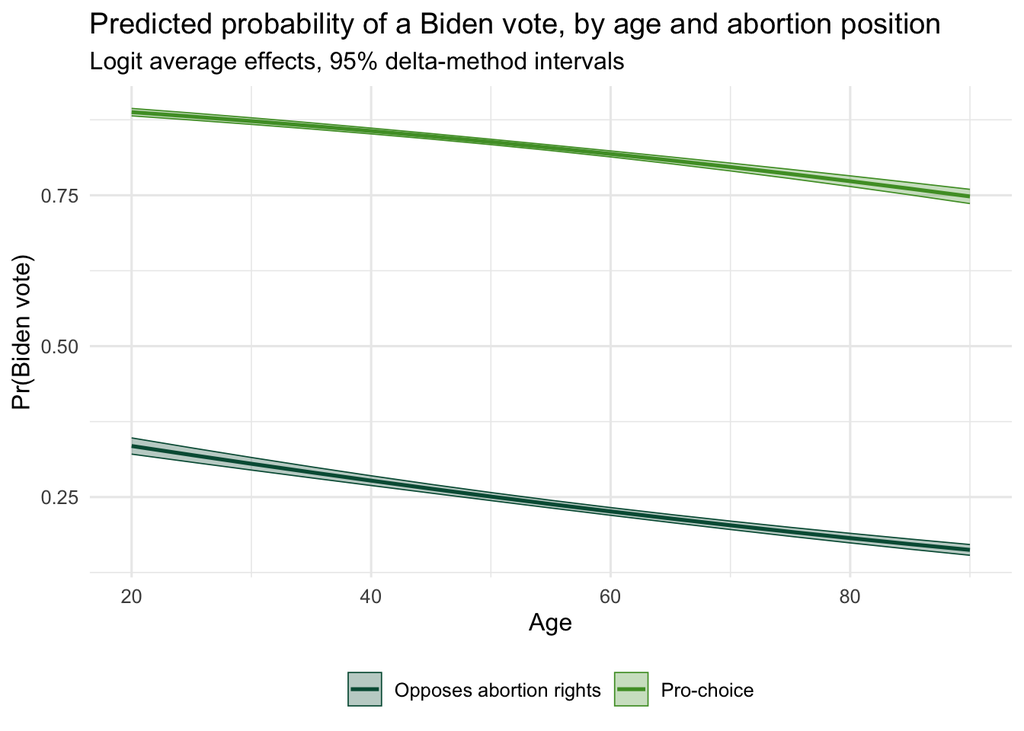

```r
# Reconstruct the estimation sample: na.action() returns the rows glm dropped
# for missingness, so `esample` is exactly the data the model was fit on.
cesa$used <- TRUE
cesa$used[na.action(m_logit)] <- FALSE
esample <- cesa %>% filter(used == TRUE)

b <- coef(m_logit)      # beta-hat
V <- vcov(m_logit)      # its estimated sampling variance -- the delta method's input

age_grid <- seq(20, 90, by = 5)

# Average effects with a delta-method interval, in four steps.
#   quantity:  pbar(beta) = (1/n) * sum_i Lambda(x_i beta)
#   gradient:  g = (1/n) * sum_i lambda(x_i b) * x_i, one per coefficient
# lambda() is the logistic PDF, so each row of X is weighted by how responsive
# that respondent's own probability is.
avg_delta <- function(a, pro_value) {
  cf      <- esample            # counterfactual COPY -- never overwrite esample
  cf$age  <- a                  # (1) everyone is this age ...
  cf$pro  <- pro_value          #     ... and holds this abortion position

  X    <- model.matrix(~ age + white + pro, data = cf)
  xb   <- as.vector(X %*% b)
  p    <- plogis(xb)            # every respondent's predicted probability
  dens <- p * (1 - p)           # lambda(xb): the logistic PDF, from question 1

  g  <- colMeans(dens * X)                       # (2) gradient of the average
  se <- sqrt(as.vector(t(g) %*% V %*% g))        # (3) delta-method SE: g' V g

  tibble(age = a, pro = pro_value,
         p  = mean(p),
         lb = mean(p) - 1.96 * se,               # (4) symmetric, probability scale
         ub = mean(p) + 1.96 * se)
}

avg_effects <- map_dfr(c(0, 1), function(pv) map_dfr(age_grid, avg_delta, pro_value = pv)) %>%
  mutate(pro = factor(pro, levels = c(0, 1),
                      labels = c("Opposes abortion rights", "Pro-choice")))

ggplot(avg_effects, aes(age, p, color = pro, fill = pro)) +
  geom_ribbon(aes(ymin = lb, ymax = ub), alpha = 0.3, linewidth = 0.3) +
  geom_line(linewidth = 0.9) +
  labs(title = "Predicted probability of a Biden vote, by age and abortion position",
       subtitle = "Logit average effects, 95% delta-method intervals",
       x = "Age", y = "Pr(Biden vote)", color = NULL, fill = NULL) +
  scale_color_manual(values = bu_two) +
  scale_fill_manual(values = bu_two) +
  theme_bu() +
  theme(legend.position = "bottom")
```

### Probit: at-means effects

One constructed respondent instead of the whole sample, every covariate we are not varying held at its central tendency — the **mode** for `white`, since the mean of a dummy describes nobody. The delta method here is the same calculation with $n = 1$, so we can check it against `predict(type = "response", se.fit = TRUE)`, which computes this standard error by this method. I recommend using the `se.fit = TRUE` standard errors in at-mean predictions to save yourselves the trouble of computing them, but want you to see how and to have code with which to do it. Please note that this packaged method will not make sense with average predictions.

```r
b_p <- coef(m_probit)
V_p <- vcov(m_probit)

# Central tendencies from the estimation sample, so they describe what the model saw.
white_mode <- as.numeric(names(sort(table(esample$white), decreasing = TRUE))[1])

# Out-of-sample data: ONE respondent, walked across the age grid at each value of pro.
mem <- expand_grid(age = age_grid, pro = c(0, 1)) %>%
  mutate(white = white_mode)

# One row per scenario, so the PDF is a scalar and factors out:
#   se(p-hat) = phi(xb) * sqrt(x' V x)
# That second factor is the ML standard error of the linear prediction.
Xm     <- model.matrix(~ age + white + pro, data = mem)
xb     <- as.vector(Xm %*% b_p)
se_lin <- sqrt(diag(Xm %*% V_p %*% t(Xm)))          # (2) SE of xb
se     <- dnorm(xb) * se_lin                        # (3) scaled by the PDF

at_means <- mem %>%
  mutate(p  = pnorm(xb),
         lb = pnorm(xb) - 1.96 * se,                # (4)
         ub = pnorm(xb) + 1.96 * se,
         pro = factor(pro, levels = c(0, 1),
                      labels = c("Opposes abortion rights", "Pro-choice")))

# Check the hand calculation against R's. stopifnot() is silent when it passes
# and stops the render when it fails.
stopifnot(isTRUE(all.equal(se, predict(m_probit, newdata = mem, type = "response",
                                       se.fit = TRUE)$se.fit,
                           check.attributes = FALSE)))
```

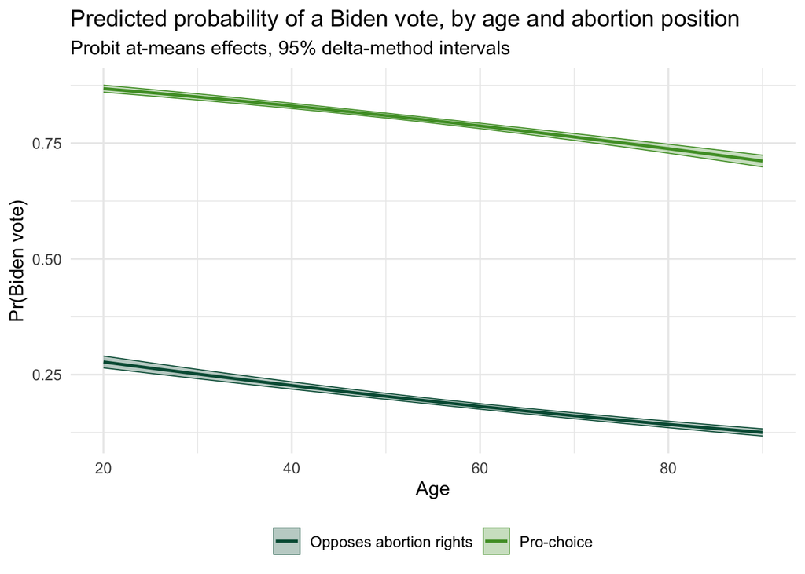

```r
ggplot(at_means, aes(age, p, color = pro, fill = pro)) +
  geom_ribbon(aes(ymin = lb, ymax = ub), alpha = 0.3, linewidth = 0.3) +
  geom_line(linewidth = 0.9) +
  labs(title = "Predicted probability of a Biden vote, by age and abortion position",
       subtitle = "Probit at-means effects, 95% delta-method intervals",
       x = "Age", y = "Pr(Biden vote)", color = NULL, fill = NULL) +
  scale_color_manual(values = bu_two) +
  scale_fill_manual(values = bu_two) +
  theme_bu() +
  theme(legend.position = "bottom")
```

The two plots look almost the same, and they should — two links on the same binomial likelihood, and these predictions never get near the tails of the CDFs where the links part ways.

The vertical distance between the two lines *is* the effect of the abortion itemin probability at each age — about .591 at age 20, .586 at age 90. Nearly constant, because over this age range $x\beta$ moves too little for the lines to curve much at all. Out in the flat tails the same shift would be worth a fraction of that.

### What you would actually write

This text could refer to either of the plots, though I’ll talk about the logit:

> Figure 1 plots the predictions from the logit model. The most striking effect is the difference in vote choice depending on whether a voter is pro-choice or not. Pro-choice voters are 55 to 59 percentage points more likely to vote for Biden across the range of age. Vote choice varies relatively little across age, a total of about a 17 point decline over the entire range. Both of the predictions lines remain strictly above (pro-choice) or below (anti-abortion) the $Pr(y=.5)$ threshold, suggesting even a 17 point change (over 70 years) is not likely to shift a hypothetical voter from one candidate to the other. The mild negative slope suggests both groups become slightly less likely to support Biden as age increases; older voters mildly prefer Trump in this particular election.

Back to top